# KNN

### Load in Data

```r
# get the min-max normalized train and test data from rds
# (created in 09_Clean_Data.Rmd, same 50/50 split used by the other models)
song_train <- readRDS("rds/song_train_norm.rds")
song_test <- readRDS("rds/song_test_norm.rds")
str(song_train)
```

```
## 'data.frame':    22500 obs. of  26 variables:
##  $ genreedm                      : num  0 0 0 0 0 0 0 0 0 0 ...
##  $ genrehiphop                   : num  0 0 0 0 0 0 1 1 1 0 ...
##  $ genreindie                    : num  0 0 0 0 0 0 0 0 0 0 ...
##  $ genrelatin                    : num  0 0 1 1 0 0 0 0 0 0 ...
##  $ genrepop                      : num  1 0 0 0 1 0 0 0 0 0 ...
##  $ genrernb                      : num  0 0 0 0 0 1 0 0 0 1 ...
##  $ genrerock                     : num  0 0 0 0 0 0 0 0 0 0 ...
##  $ energy                        : num  0.555 0.945 0.55 0.796 0.441 0.165 0.525 0.769 0.971 0.885 ...
##  $ valence                       : num  0.383 0.591 0.568 0.385 0.354 0.214 0.556 0.622 0.955 0.19 ...
##  $ danceability                  : num  0.665 0.565 0.771 0.604 0.341 0.313 0.558 0.231 0.851 0.852 ...
##  $ acousticness                  : num  0.095 0.608 0.565 0.259 0.452 0.44 0.652 0.53 0.188 0.643 ...
##  $ instrumentalness              : num  0.012 0.068 0.353 0.034 0.26 0.114 0.013 0.039 0.074 0.121 ...
##  $ tempo_bpm                     : num  0.514 0.407 0.393 0.486 0.429 ...
##  $ song_length_sec               : num  0.558 0.174 0.518 0.512 0.488 ...
##  $ label_tierindie_label         : num  0 1 0 1 0 0 0 0 0 0 ...
##  $ label_tiermajor               : num  0 0 1 0 1 0 1 0 0 1 ...
##  $ marketing_budget              : num  0.4815 0.3552 0.1111 0.0779 0.0798 ...
##  $ playlist_adds_first_month     : num  0.1132 0.0943 0.0377 0.2453 0.2453 ...
##  $ editorial_playlist            : num  0 0 1 0 0 0 0 0 0 0 ...
##  $ tiktok_virality               : num  0.3071 0.0169 0.101 0.2427 0.2793 ...
##  $ artist_prior_monthly_listeners: num  0.000016 0.003764 0.003916 0.000028 0 ...
##  $ featured_artist               : num  1 0 0 0 0 0 0 0 0 0 ...
##  $ first_month_streams           : num  0.003625 0.000166 0.00085 0.000572 0.008256 ...
##  $ halflife_days                 : num  0.01564 0.00447 0.07374 0.07486 0.03911 ...
##  $ slow_burner                   : num  0 0 0 0 0 0 0 1 0 0 ...
##  $ hit                           : Factor w/ 2 levels "0","1": 1 1 1 1 1 1 1 1 1 2 ...
```

### Prepare Data

```r
# KNN is distance based, so it needs all-numeric predictors on the same scale.
# The rds data is already dummy-coded and min-max normalized.
# slow_burner is dropped because it is another outcome label, not a predictor.
predictors <- setdiff(names(song_train), c("hit", "slow_burner"))

knn_train <- song_train[, predictors]
knn_test <- song_test[, predictors]
knn_train_labels <- song_train$hit
knn_test_labels <- song_test$hit

# Check that both sets have a similar share of hits
prop.table(table(knn_train_labels))
```

```
## knn_train_labels
##          0          1
## 0.90102222 0.09897778
```

```r
prop.table(table(knn_test_labels))
```

```
## knn_test_labels
##         0         1
## 0.8989778 0.1010222
```

### Helper functions

```r
# Only ~10% of songs are hits, so accuracy alone is misleading (predicting
# "not a hit" every time is already ~90% accurate). We judge every version
# on kappa instead.

# turn knn() output into the probability of being a hit
# (knn() reports the share of votes for the winning class)
hit_prob <- function(pred) {
  win_prob <- attr(pred, "prob")
  ifelse(pred == "1", win_prob, 1 - win_prob)
}

# turn hit probabilities into 0/1 predictions
to_bin <- function(prob, cutoff = 0.5) {
  factor(ifelse(prob >= cutoff, "1", "0"), levels = c("0", "1"))
}

# one row of metrics for the comparison table at the end
get_metrics <- function(cm) {
  c(accuracy = unname(cm$overall["Accuracy"]),
    kappa = unname(cm$overall["Kappa"]),
    sensitivity = unname(cm$byClass["Sensitivity"]),
    specificity = unname(cm$byClass["Specificity"]),
    precision = unname(cm$byClass["Pos Pred Value"]))
}
```

### Baseline Model

**What we are doing:** building a starting point to measure every improvement against.

**How:** we use the common rule of thumb K = square root of the number of training rows, and a plain majority vote: a song is called a hit only if more than half of its K nearest neighbors are hits.

```r
# Rule of thumb: K = square root of the number of training rows (made odd to
# avoid ties), with a plain majority vote (a song is a hit only if more than
# half of its neighbors are hits).
base_k <- round(sqrt(nrow(knn_train)))
if (base_k %% 2 == 0) base_k <- base_k + 1
base_k
```

```
## [1] 151
```

```r
set.seed(12345)
knn_base <- knn(train = knn_train, test = knn_test,
                cl = knn_train_labels, k = base_k, prob = TRUE)
knn_base_prob <- hit_prob(knn_base)

cm_knn_base <- confusionMatrix(to_bin(knn_base_prob), knn_test_labels, positive = "1")
cm_knn_base
```

```
## Confusion Matrix and Statistics
##
##           Reference
## Prediction     0     1
##          0 20227  2273
##          1     0     0
##
##                Accuracy : 0.899
##                  95% CI : (0.895, 0.9029)
##     No Information Rate : 0.899
##     P-Value [Acc > NIR] : 0.5056
##
##                   Kappa : 0
##
##  Mcnemar's Test P-Value : <2e-16
##
##             Sensitivity : 0.000
##             Specificity : 1.000
##          Pos Pred Value :   NaN
##          Neg Pred Value : 0.899
##              Prevalence : 0.101
##          Detection Rate : 0.000
##    Detection Prevalence : 0.000
##       Balanced Accuracy : 0.500
##
##        'Positive' Class : 1
##
```

### Improvement 1: Adjust K

**What we are doing:** changing only the number of neighbors, K. The vote stays a majority vote, so any change in kappa comes from K alone.

**How:** we run KNN for every odd K from 1 to 39 (odd so the vote cannot tie), compute kappa on the test set for each, and keep the K with the highest kappa. We go smaller than the baseline because the baseline’s problem was too many neighbors: the more neighbors vote, the less likely the rare hits are to be the majority.

```r
# Step along smaller K values (odd only), still with a majority vote, and see
# which K gives the highest kappa. The hit probabilities for each K are kept
# so the later improvements can reuse them without re-running knn().
k_values <- seq(1, 39, by = 2)
knn_probs <- list()

set.seed(12345)
for (k in k_values) {
  knn_pred <- knn(train = knn_train, test = knn_test,
                  cl = knn_train_labels, k = k, prob = TRUE)
  knn_probs[[as.character(k)]] <- hit_prob(knn_pred)
}

k_only <- data.frame(k = k_values, kappa = NA, sensitivity = NA)
for (i in 1:nrow(k_only)) {
  cm <- confusionMatrix(to_bin(knn_probs[[as.character(k_only$k[i])]]),
                        knn_test_labels, positive = "1")
  k_only$kappa[i] <- cm$overall["Kappa"]
  k_only$sensitivity[i] <- cm$byClass["Sensitivity"]
}
k_only
```

```
##     k      kappa sensitivity
## 1   1 0.16894170 0.203695557
## 2   3 0.15560130 0.124945007
## 3   5 0.12727294 0.089749230
## 4   7 0.10357166 0.068631764
## 5   9 0.08903556 0.057193137
## 6  11 0.07226760 0.044874615
## 7  13 0.06152450 0.038275407
## 8  15 0.05372647 0.033435988
## 9  17 0.04176576 0.025956885
## 10 19 0.03880092 0.023757149
## 11 21 0.04342174 0.026396832
## 12 23 0.03961138 0.024637044
## 13 25 0.03669684 0.022877255
## 14 27 0.03347908 0.021117466
## 15 29 0.03296479 0.019797624
## 16 31 0.02676200 0.015838099
## 17 33 0.01981026 0.011438627
## 18 35 0.01386919 0.007919050
## 19 37 0.01230733 0.007039155
## 20 39 0.01065122 0.006159261
```

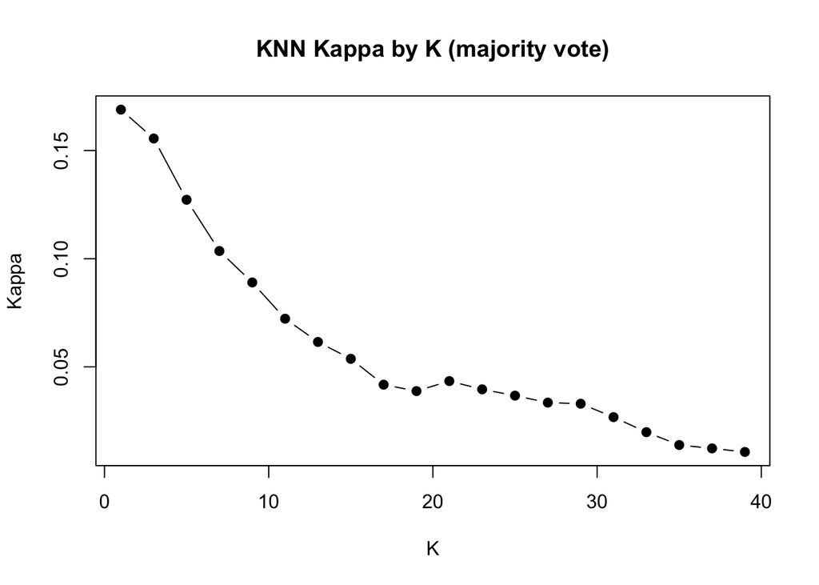

```r
plot(k_only$k, k_only$kappa, type = "b", pch = 19,
     xlab = "K", ylab = "Kappa", main = "KNN Kappa by K (majority vote)")
```

```r
k_majority <- k_only$k[which.max(k_only$kappa)]
k_majority
```

```
## [1] 1
```

```r
cm_knn_k <- confusionMatrix(to_bin(knn_probs[[as.character(k_majority)]]),
                            knn_test_labels, positive = "1")
cm_knn_k
```

```
## Confusion Matrix and Statistics
##
##           Reference
## Prediction     0     1
##          0 19081  1810
##          1  1146   463
##
##                Accuracy : 0.8686
##                  95% CI : (0.8641, 0.873)
##     No Information Rate : 0.899
##     P-Value [Acc > NIR] : 1
##
##                   Kappa : 0.1689
##
##  Mcnemar's Test P-Value : <2e-16
##
##             Sensitivity : 0.20370
##             Specificity : 0.94334
##          Pos Pred Value : 0.28776
##          Neg Pred Value : 0.91336
##              Prevalence : 0.10102
##          Detection Rate : 0.02058
##    Detection Prevalence : 0.07151
##       Balanced Accuracy : 0.57352
##
##        'Positive' Class : 1
##
```

Smaller K helps, but kappa keeps falling as K grows: under a majority vote, larger K still misses most hits.

### Improvement 2: Adjust the threshold

**What we are doing:** changing only the threshold (cutoff) used to call a song a hit. A majority vote is really a cutoff of 0.5 on the share of neighbors that are hits. Since only ~10% of songs are hits, asking for more than half the neighbors to be hits is a very high bar, so we try lower cutoffs.

**How:** we take the share of neighbors that are hits as each song’s hit probability, step the cutoff from 0.05 to 0.5, compute kappa for each, and keep the cutoff with the highest kappa.

**Which K this uses:** the baseline K, *not* the best K from Improvement 1. There are two reasons. First, it keeps the steps separate: Improvement 1 changes only K, Improvement 2 changes only the cutoff, and both are compared with the same baseline. Second, the best K from Improvement 1 is K = 1, and with a single neighbor the hit probability can only be 0 or 1, so every cutoff between 0.05 and 0.5 gives exactly the same predictions. The threshold only matters when there are enough neighbors for the probability to take values in between. Tuning the two settings together is Improvement 3.

```r
# The majority vote is really a 0.5 cutoff on the share of neighbors that are
# hits. Because hits are rare, a lower cutoff makes more sense. Go back to the
# baseline K and change only the cutoff, to see what the threshold does on
# its own.
cutoffs <- seq(0.05, 0.5, by = 0.05)

cutoff_only <- data.frame(cutoff = cutoffs, kappa = NA, sensitivity = NA,
                          specificity = NA)
for (i in 1:nrow(cutoff_only)) {
  cm <- confusionMatrix(to_bin(knn_base_prob, cutoff_only$cutoff[i]),
                        knn_test_labels, positive = "1")
  cutoff_only$kappa[i] <- cm$overall["Kappa"]
  cutoff_only$sensitivity[i] <- cm$byClass["Sensitivity"]
  cutoff_only$specificity[i] <- cm$byClass["Specificity"]
}
cutoff_only
```

```
##    cutoff       kappa sensitivity specificity
## 1    0.05 0.113528392 0.845578531   0.4891976
## 2    0.10 0.240670437 0.552133744   0.8157908
## 3    0.15 0.257322384 0.355917290   0.9146191
## 4    0.20 0.242576578 0.251649802   0.9542196
## 5    0.25 0.203223558 0.188297404   0.9676670
## 6    0.30 0.136954545 0.107787066   0.9837346
## 7    0.35 0.051146990 0.031236252   0.9982696
## 8    0.40 0.002280925 0.001319842   0.9999506
## 9    0.45 0.000000000 0.000000000   1.0000000
## 10   0.50 0.000000000 0.000000000   1.0000000
```

```r
cutoff_at_base <- cutoff_only$cutoff[which.max(cutoff_only$kappa)]
cutoff_at_base
```

```
## [1] 0.15
```

```r
cm_knn_cutoff <- confusionMatrix(to_bin(knn_base_prob, cutoff_at_base),
                                 knn_test_labels, positive = "1")
cm_knn_cutoff
```

```
## Confusion Matrix and Statistics
##
##           Reference
## Prediction     0     1
##          0 18500  1464
##          1  1727   809
##
##                Accuracy : 0.8582
##                  95% CI : (0.8536, 0.8627)
##     No Information Rate : 0.899
##     P-Value [Acc > NIR] : 1
##
##                   Kappa : 0.2573
##
##  Mcnemar's Test P-Value : 3.517e-06
##
##             Sensitivity : 0.35592
##             Specificity : 0.91462
##          Pos Pred Value : 0.31901
##          Neg Pred Value : 0.92667
##              Prevalence : 0.10102
##          Detection Rate : 0.03596
##    Detection Prevalence : 0.11271
##       Balanced Accuracy : 0.63527
##
##        'Positive' Class : 1
##
```

Lowering the cutoff lets the baseline K finally catch hits. Improvements 1 and 2 each changed one setting on its own; the next step tunes them together.

### Improvement 3: Tune K and the threshold together

**What we are doing:** tuning K and the cutoff at the same time, because the best value of one depends on the other. Under a majority vote the smallest K won (Improvement 1), but once the cutoff is lowered a larger K becomes useful: more neighbors give finer-grained probabilities (K = 15 can give 0/15, 1/15, 2/15, …) for the cutoff to work with.

**How:** we compute kappa for every combination of K (1 to 39) and cutoff (0.05 to 0.5), find the best cutoff for each K, and plot kappa against K. Rather than taking the single highest kappa, we pick the K at the elbow of that curve, where adding more neighbors stops helping.

```r
# The best K depends on the cutoff: under a majority vote small K wins, but a
# larger K gives finer-grained probabilities that pay off once the cutoff is
# lowered. So step along every combination of K and cutoff.
k_results <- expand.grid(cutoff = cutoffs, k = k_values)[, c("k", "cutoff")]
k_results[, c("accuracy", "kappa", "sensitivity", "specificity")] <- NA

for (row in 1:nrow(k_results)) {
  cm <- confusionMatrix(to_bin(knn_probs[[as.character(k_results$k[row])]],
                               k_results$cutoff[row]),
                        knn_test_labels, positive = "1")
  k_results$accuracy[row] <- cm$overall["Accuracy"]
  k_results$kappa[row] <- cm$overall["Kappa"]
  k_results$sensitivity[row] <- cm$byClass["Sensitivity"]
  k_results$specificity[row] <- cm$byClass["Specificity"]
}

# best cutoff for each K
best_by_k <- do.call(rbind, lapply(split(k_results, k_results$k),
                                   function(d) d[which.max(d$kappa), ]))
best_by_k
```

```
##     k cutoff  accuracy     kappa sensitivity specificity
## 1   1   0.05 0.8686222 0.1689417   0.2036956   0.9433431
## 3   3   0.05 0.8062667 0.1967228   0.4104707   0.8507441
## 5   5   0.20 0.8799111 0.2324310   0.2494501   0.9507589
## 7   7   0.15 0.8589778 0.2598623   0.3572371   0.9153607
## 9   9   0.20 0.8367556 0.2659291   0.4447866   0.8808029
## 11 11   0.20 0.8758222 0.2728841   0.3180818   0.9384980
## 13 13   0.20 0.8618667 0.2743489   0.3704355   0.9170910
## 15 15   0.15 0.8485333 0.2775280   0.4241091   0.8962278
## 17 17   0.20 0.8731111 0.2827759   0.3427189   0.9327137
## 19 19   0.20 0.8638667 0.2863180   0.3827541   0.9179315
## 21 21   0.15 0.8536444 0.2843536   0.4175099   0.9026549
## 23 23   0.20 0.8712889 0.2841003   0.3515178   0.9296979
## 25 25   0.15 0.8320000 0.2716100   0.4725033   0.8723983
## 27 27   0.15 0.8558667 0.2840456   0.4087110   0.9061156
## 29 29   0.15 0.8479556 0.2804926   0.4315882   0.8947446
## 31 31   0.15 0.8400000 0.2783319   0.4566652   0.8830771
## 33 33   0.20 0.8721778 0.2750298   0.3343599   0.9326148
## 35 35   0.15 0.8521778 0.2869505   0.4276287   0.8998863
## 37 37   0.15 0.8465778 0.2832351   0.4417070   0.8920749
## 39 39   0.20 0.8725333 0.2828167   0.3449186   0.9318238
```

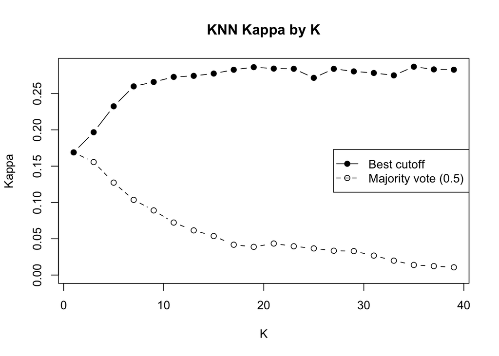

```r
# kappa with a plain majority vote (cutoff 0.5) vs. the best cutoff for each K
majority <- k_results[k_results$cutoff == 0.5, ]
plot(best_by_k$k, best_by_k$kappa, type = "b", pch = 19,
     ylim = range(0, best_by_k$kappa),
     xlab = "K", ylab = "Kappa", main = "KNN Kappa by K")
lines(majority$k, majority$kappa, type = "b", pch = 1, lty = 2)
legend("right", legend = c("Best cutoff", "Majority vote (0.5)"),
       pch = c(19, 1), lty = c(1, 2))
```

```r
# Kappa levels off at the elbow around K = 15; larger K adds almost nothing,
# so we use K = 15 with the cutoff that gives it the highest kappa.
best_k <- 15
best <- best_by_k[best_by_k$k == best_k, ]
best
```

```
##     k cutoff  accuracy    kappa sensitivity specificity
## 15 15   0.15 0.8485333 0.277528   0.4241091   0.8962278
```

```r
cm_knn_both <- confusionMatrix(to_bin(knn_probs[[as.character(best$k)]], best$cutoff),
                               knn_test_labels, positive = "1")
cm_knn_both
```

```
## Confusion Matrix and Statistics
##
##           Reference
## Prediction     0     1
##          0 18128  1309
##          1  2099   964
##
##                Accuracy : 0.8485
##                  95% CI : (0.8438, 0.8532)
##     No Information Rate : 0.899
##     P-Value [Acc > NIR] : 1
##
##                   Kappa : 0.2775
##
##  Mcnemar's Test P-Value : <2e-16
##
##             Sensitivity : 0.42411
##             Specificity : 0.89623
##          Pos Pred Value : 0.31472
##          Neg Pred Value : 0.93265
##              Prevalence : 0.10102
##          Detection Rate : 0.04284
##    Detection Prevalence : 0.13613
##       Balanced Accuracy : 0.66017
##
##        'Positive' Class : 1
##
```

### Compare all versions

```r
# test-set results for every version
knn_compare <- rbind(get_metrics(cm_knn_base), get_metrics(cm_knn_k),
                     get_metrics(cm_knn_cutoff), get_metrics(cm_knn_both))
rownames(knn_compare) <- c(
  paste0("Baseline (K = ", base_k, ", majority vote)"),
  paste0("Improvement 1: Adjust K (K = ", k_majority, ")"),
  paste0("Improvement 2: Adjust threshold (K = ", base_k,
         ", cutoff = ", cutoff_at_base, ")"),
  paste0("Improvement 3: K and threshold together (K = ", best$k,
         ", cutoff = ", best$cutoff, ")"))
round(knn_compare, 4)
```

```
##                                                                 accuracy  kappa
## Baseline (K = 151, majority vote)                                 0.8990 0.0000
## Improvement 1: Adjust K (K = 1)                                   0.8686 0.1689
## Improvement 2: Adjust threshold (K = 151, cutoff = 0.15)          0.8582 0.2573
## Improvement 3: K and threshold together (K = 15, cutoff = 0.15)   0.8485 0.2775
##                                                                 sensitivity
## Baseline (K = 151, majority vote)                                    0.0000
## Improvement 1: Adjust K (K = 1)                                      0.2037
## Improvement 2: Adjust threshold (K = 151, cutoff = 0.15)             0.3559
## Improvement 3: K and threshold together (K = 15, cutoff = 0.15)      0.4241
##                                                                 specificity
## Baseline (K = 151, majority vote)                                    1.0000
## Improvement 1: Adjust K (K = 1)                                      0.9433
## Improvement 2: Adjust threshold (K = 151, cutoff = 0.15)             0.9146
## Improvement 3: K and threshold together (K = 15, cutoff = 0.15)      0.8962
##                                                                 precision
## Baseline (K = 151, majority vote)                                     NaN
## Improvement 1: Adjust K (K = 1)                                    0.2878
## Improvement 2: Adjust threshold (K = 151, cutoff = 0.15)           0.3190
## Improvement 3: K and threshold together (K = 15, cutoff = 0.15)    0.3147
```

### Final Model

```r
# Final model = K and cutoff tuned together (Improvement 3)
song_knn_predict <- knn_probs[[as.character(best$k)]]
names(song_knn_predict) <- rownames(song_test)
song_knn_bin <- to_bin(song_knn_predict, best$cutoff)
summary(song_knn_bin)
```

```
##     0     1
## 19437  3063
```

```r
cm_knn <- cm_knn_both
cm_knn
```

```
## Confusion Matrix and Statistics
##
##           Reference
## Prediction     0     1
##          0 18128  1309
##          1  2099   964
##
##                Accuracy : 0.8485
##                  95% CI : (0.8438, 0.8532)
##     No Information Rate : 0.899
##     P-Value [Acc > NIR] : 1
##
##                   Kappa : 0.2775
##
##  Mcnemar's Test P-Value : <2e-16
##
##             Sensitivity : 0.42411
##             Specificity : 0.89623
##          Pos Pred Value : 0.31472
##          Neg Pred Value : 0.93265
##              Prevalence : 0.10102
##          Detection Rate : 0.04284
##    Detection Prevalence : 0.13613
##       Balanced Accuracy : 0.66017
##
##        'Positive' Class : 1
##
```

### Save to RDS

```r
# save probabilities to rds to be used in stacked model
saveRDS(song_knn_predict, "rds/knn_predict.rds")

# save confusion matrix to rds
saveRDS(cm_knn, "rds/cm_knn.rds")
```